# Homework 3

Jun Ryu

2023-05-23

## Question 1

### a)

```r
cancer <- read.table("cancer.txt", header = T)
head(cancer)
```

```
##          Region All.cancers Lung Colon Melanoma F.breast Pancreas Leukemia
## 1   Connecticut       584.1 54.4  52.4     27.9    133.9     16.2     13.7
## 2         Maine       598.9 70.4  53.6     24.6    128.9     13.1     20.7
## 3 Massachusetts       571.0 62.6  50.7     26.0    131.7     13.3     16.0
## 4 New-Hampshire       567.6 60.4  48.8     33.0    128.8     14.4     15.7
## 5  Rhode-Island       603.3 71.6  54.5     24.7    139.2     11.8     16.4
## 6       Vermont       529.7 67.7  40.2     33.8    133.7     14.0     13.3
##   Ovarian Cervix Prostate Liver
## 1    12.1    6.5    172.8   9.8
## 2    11.8    7.5    165.7   6.2
## 3    11.8    5.3    166.9  10.9
## 4    12.5    5.1    158.6   6.5
## 5    11.8    7.0    170.1  10.8
## 6    10.8    7.9    148.0   9.5
```

```r
apply(cancer[,2:ncol(cancer)],2,sd)
```

```
## All.cancers        Lung       Colon    Melanoma    F.breast    Pancreas
##   47.857634   14.724588    7.262243    5.245611    7.888396    1.482258
##    Leukemia     Ovarian      Cervix    Prostate       Liver
##    2.255171    1.358915    1.421959   16.858436    2.241009
```

### b)

```r
covar <- cov(cancer[,2:ncol(cancer)])
values <- eigen(covar)$values

# eigenvectors are already ordered in decreasing order of eigenvalues
vectors <- eigen(covar)$vectors

# our principal components are essentially the eigenvectors
pc <- matrix(vectors, ncol = 11)
rownames(pc) <- colnames(cancer[,2:ncol(cancer)])
colnames(pc) <- paste("PC", 1:11, sep = "")
pc
```

```
##                     PC1          PC2         PC3         PC4          PC5
## All.cancers 0.948911183  0.048606436  0.20935669  0.10770752  0.115235991
## Lung        0.173707714  0.668729611 -0.56080328 -0.41636726 -0.079471933
## Colon       0.098867058  0.127018189 -0.01199414  0.54795323 -0.397823583
## Melanoma    0.029715889 -0.112583098  0.14293336 -0.28359794  0.694490359
## F.breast    0.077227953 -0.127033747  0.46441765 -0.63576945 -0.555746943
## Pancreas    0.015969632  0.005649558  0.06769941  0.02884992  0.032789987
## Leukemia    0.019995381 -0.039163522  0.04279231  0.08030527 -0.028433176
## Ovarian     0.004948948 -0.004370774  0.07143164 -0.02340922 -0.057920669
## Cervix      0.014052752  0.035246938 -0.01491943  0.05488954  0.006994686
## Prostate    0.227792155 -0.708933677 -0.62503708 -0.12892118 -0.147295540
## Liver       0.002286687  0.008824253  0.05478220  0.05187759 -0.063138084
##                      PC6          PC7         PC8         PC9        PC10
## All.cancers -0.151902582  0.025821125 -0.05163051  0.03245476 -0.03184170
## Lung         0.118220768 -0.012290183  0.08765643 -0.04797850  0.05448703
## Colon        0.711305149 -0.086208795  0.01615325  0.01060887  0.00232018
## Melanoma     0.605596140 -0.113265129  0.14449875 -0.01166668 -0.01237297
## F.breast     0.199046073 -0.015777078  0.03263704  0.05340703  0.02882697
## Pancreas    -0.009420867 -0.187574322 -0.18120002 -0.48984821  0.80727359
## Leukemia    -0.024805801  0.572854039  0.75927739 -0.08114244  0.26637074
## Ovarian     -0.016496386  0.008520542  0.01949652 -0.83868297 -0.43471333
## Cervix      -0.026794542 -0.209819414  0.32218462 -0.17376917 -0.27853322
## Prostate     0.094279052 -0.057460006  0.03201328 -0.05044051  0.02786371
## Liver       -0.200114261 -0.753610008  0.50289278  0.10430398  0.07107011
##                      PC11
## All.cancers -0.0045249774
## Lung        -0.0369717911
## Colon       -0.0408123799
## Melanoma    -0.0502259945
## F.breast     0.0673818868
## Pancreas     0.1829592658
## Leukemia    -0.0784928893
## Ovarian     -0.3128281937
## Cervix       0.8596244870
## Prostate    -0.0003258794
## Liver       -0.3367980425
```

The first component has an extreme positive load of All.cancers. The second component also sees an extreme (but to a lesser degree than the first) positive load of the variable Lung as well as an extreme negative load of the variable Prostate. These align with the variables with the largest standard deviations in part a); All.cancers had the highest standard deviation, and Prostate the next, then Lung right after.

### c)

```r
# we scale the data now
cancer_rev <- scale(cancer[,2:ncol(cancer)])
covar <- cov(cancer_rev)
values <- eigen(covar)$values
vectors <- eigen(covar)$vectors

pc <- matrix(vectors, ncol = 11)
rownames(pc) <- colnames(cancer_rev)
colnames(pc) <- paste("PC", 1:11, sep = "")
pc
```

```
##                    PC1         PC2         PC3         PC4         PC5
## All.cancers -0.5010584 -0.03752827  0.13564906  0.10200653  0.00661866
## Lung        -0.2867743  0.34463886  0.24975314  0.12961783  0.53167942
## Colon       -0.3905015  0.24854728  0.20719239 -0.20988812 -0.03157362
## Melanoma    -0.1316843 -0.41857218 -0.05859752  0.60913595  0.15614063
## F.breast    -0.2764510 -0.37218720 -0.27254464 -0.03686353  0.14210375
## Pancreas    -0.3555025  0.02591798 -0.38107453  0.09964642  0.07993039
## Leukemia    -0.2406797 -0.28184171  0.30247121 -0.48821395 -0.28970563
## Ovarian     -0.1834695 -0.18665306 -0.48476086 -0.49457994  0.29556288
## Cervix      -0.3183348  0.43674873 -0.03254542  0.07805234 -0.10765380
## Prostate    -0.3061206 -0.30469450  0.22752557  0.19475514 -0.44400656
## Liver       -0.0861796  0.32523824 -0.52350067  0.13936291 -0.53413119
##                     PC6         PC7          PC8         PC9        PC10
## All.cancers -0.10905402  0.04374209  0.006792296  0.11185970 -0.18508041
## Lung        -0.28217876 -0.14537839  0.007252804  0.29034347 -0.33824243
## Colon        0.11291776  0.37193300  0.131962267 -0.70550259 -0.07120336
## Melanoma     0.38162735 -0.30791519  0.098058275 -0.31623819 -0.21670726
## F.breast    -0.57513296 -0.04175042  0.414550768 -0.10494771  0.40179558
## Pancreas     0.45035470  0.50502008  0.098916420  0.43699136  0.16737802
## Leukemia     0.27410672 -0.33568094  0.364797251  0.27142205 -0.15902722
## Ovarian      0.06044586 -0.19263901 -0.503971154 -0.13826954 -0.22490690
## Cervix       0.18024636 -0.54255118 -0.168849994 -0.04772674  0.57564539
## Prostate    -0.24994785  0.15577866 -0.581436598  0.09082973  0.03419142
## Liver       -0.20674709 -0.13637156  0.193887091 -0.01248343 -0.44882159
##                     PC11
## All.cancers  0.811210603
## Lung        -0.370950840
## Colon       -0.162640106
## Melanoma    -0.107522730
## F.breast    -0.111317074
## Pancreas    -0.157430047
## Leukemia    -0.170336907
## Ovarian      0.009368924
## Cervix       0.012902563
## Prostate    -0.303946738
## Liver       -0.086554294
```

Although the variable All.cancers still has the highest magnitude of load for the first component, it now sees a more evenly distributed loading by each of the variables. The same can be said for the second component, where we see a good distribution across all variables except All.cancers and Pancreas.

### d)

In this case, the scaled component analysis is much better. Due to All.cancers, Prostate, and Lung variables having a way greater standard deviations than other remaining variables, the unscaled component analysis led to the first two components being dominated by these variables, thus leading to unhelpful interpretations. With the scaled version, there is a better interpretation of these components.

## Question 2

### a)

```r
farmer <- read.csv("farmers.csv")
head(farmer)
```

```
##   Family DistRD Cotton Maize Sorg Millet Bull Cattle Goats
## 1     12     80    1.5   1.0    3   0.25    2      0     1
## 2     54      8    6.0   4.0    0   1.00    6     32     5
## 3     11     13    0.5   1.0    0   0.00    0      0     0
## 4     21     13    2.0   2.5    1   0.00    1      0     5
## 5     61     30    3.0   5.0    0   0.00    4     21     0
## 6     20     70    0.0   2.0    3   0.00    2      0     3
```

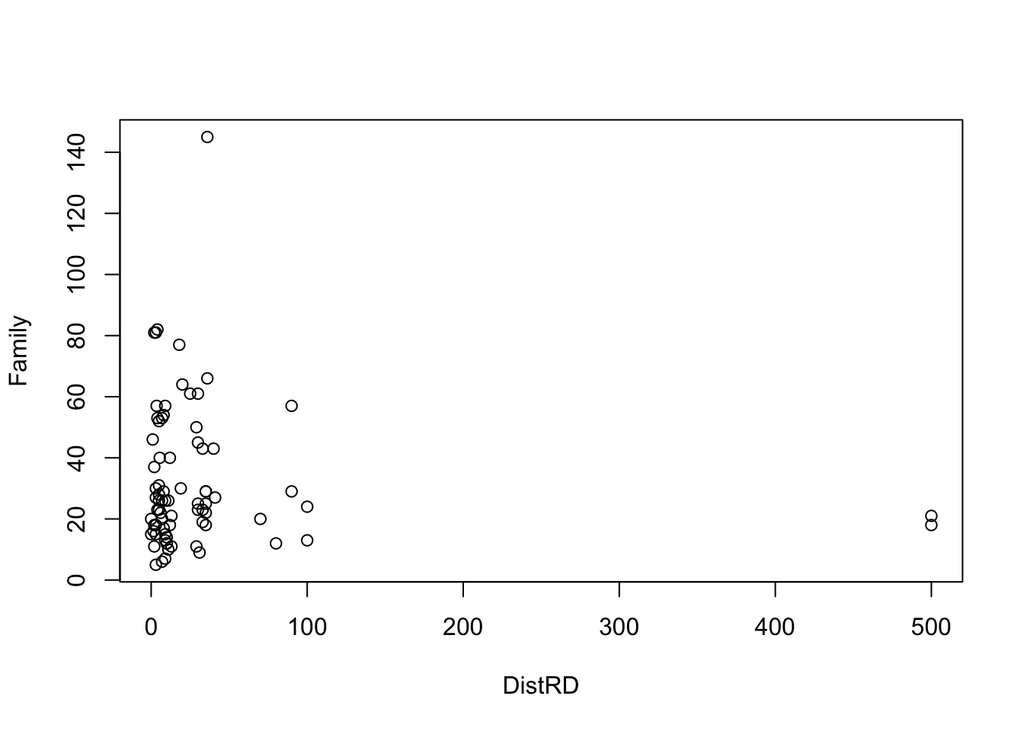

```r
plot(Family ~ DistRD, data = farmer)
```

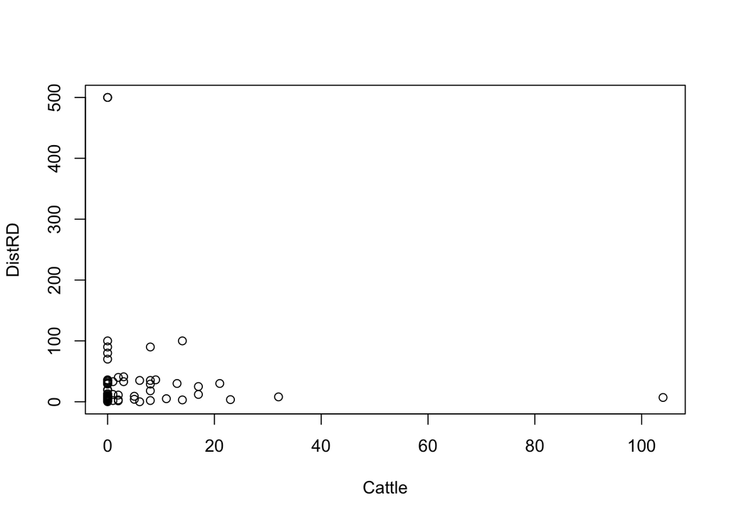

```r
plot(DistRD ~ Cattle, data = farmer)
```

There are obviously outliers in this plot. We remove these points, then plot again.

```r
farmer[farmer$DistRD > 400 | farmer$Family > 100 | farmer$Cattle > 100, ]
```

```
##    Family DistRD Cotton Maize Sorg Millet Bull Cattle Goats
## 25    145     36    9.5     7 13.0    5.5    8      9    15
## 34     53      7    0.0     1 11.0    2.0    8    104    10
## 69     18    500    2.0     1  1.5    0.5    1      0     0
## 72     21    500    5.0     1  3.0    4.0    1      0     5
```

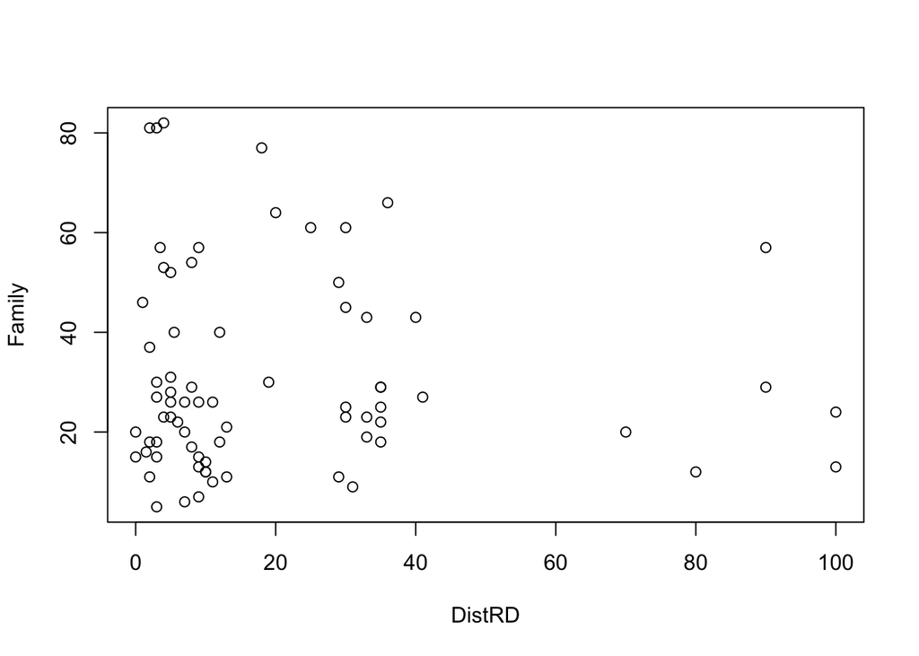

```r
# the above gives rows 25, 34, 69, and 72
farmer_rev <- farmer[-c(25,34,69,72),]
plot(Family ~ DistRD, data = farmer_rev)
```

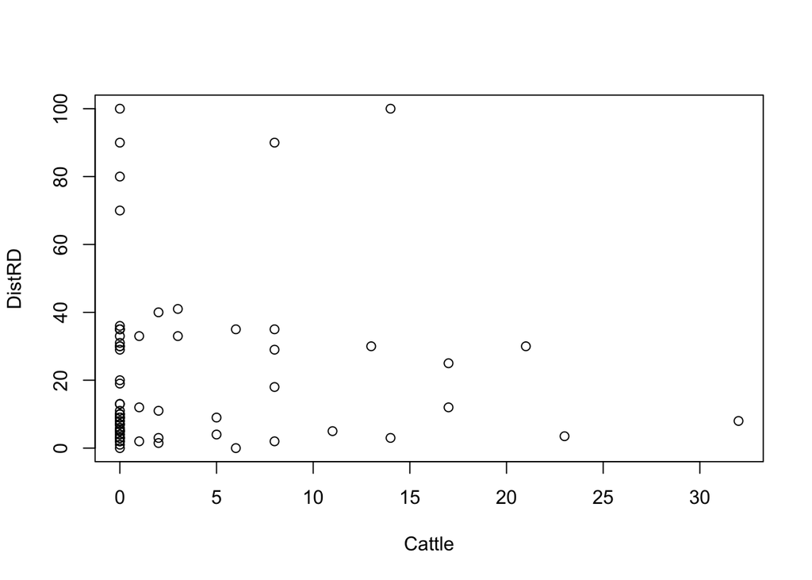

```r
plot(DistRD ~ Cattle, data = farmer_rev)
```

### b)

```r
farmer_rev <- scale(farmer_rev)
covar <- cov(farmer_rev)
values <- eigen(covar)$values
vectors <- eigen(covar)$vectors

pc <- matrix(vectors, ncol = 9)
rownames(pc) <- colnames(farmer_rev)
colnames(pc) <- paste("PC", 1:9, sep = "")
pc
```

```
##                PC1         PC2         PC3         PC4         PC5         PC6
## Family 0.434621474  0.06415400  0.10034385 -0.17226922  0.01034216 -0.02591583
## DistRD 0.006575128 -0.49114894 -0.57469380 -0.49454804 -0.37362782  0.19378408
## Cotton 0.446866772 -0.01044027  0.13284974  0.02608056 -0.22215716 -0.18615256
## Maize  0.347098193 -0.36931340  0.38614414 -0.23890526 -0.07237690 -0.27496451
## Sorg   0.204181927  0.60314126 -0.10352507  0.05084121 -0.64708317  0.22843343
## Millet 0.241415840  0.41557741 -0.10827062 -0.61650514  0.52758997  0.17503845
## Bull   0.445537389 -0.07442198 -0.02774309  0.14266531 -0.02912967 -0.15077805
## Cattle 0.356235573 -0.27030830  0.00511354  0.38047175  0.21494529  0.76141636
## Goats  0.255958314  0.05537533 -0.68532183  0.34671900  0.24816377 -0.40768696
##                 PC7         PC8         PC9
## Family  0.798420353 -0.25864268  0.24918503
## DistRD -0.022425719 -0.04653811  0.06371838
## Cotton -0.351942732  0.35212495  0.67082754
## Maize   0.026440664  0.35239164 -0.57552113
## Sorg    0.014451663  0.11443103 -0.31149050
## Millet -0.244530105  0.07481424 -0.05320632
## Bull   -0.399034883 -0.75169107 -0.16426771
## Cattle  0.001529367  0.16083553 -0.05846345
## Goats   0.134997157  0.27049429 -0.14951096
```

If we take the first 6 principal components:

```r
sum(values[1:6])/sum(values)
```

```
## [1] 0.940945
```

94% of the total variance is explained through the first 6 components, which effectively summarizes the variability.

## Question 3

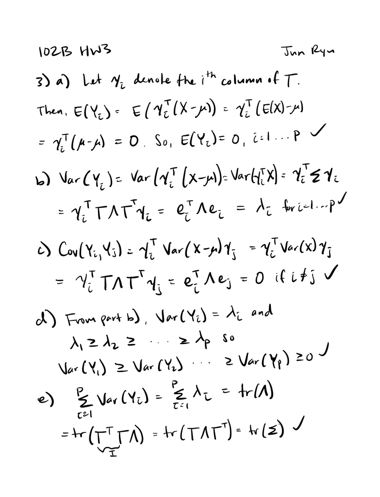

```r
knitr::include_graphics("hw3_q3_1.png")
```

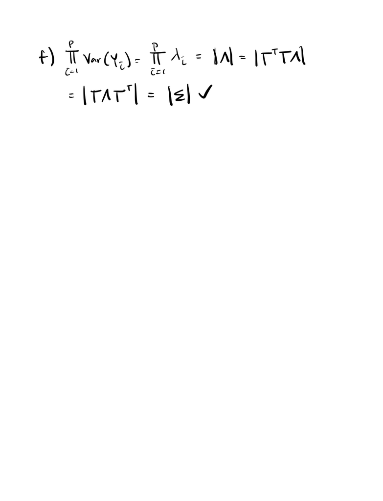

```r
knitr::include_graphics("hw3_q3_2.png")
```

## Question 4

### a)

```r
random_search1 <- function(g, alpha_choice = 1, max_its = 100, num_samples = 2, w0 = 0) {
  #random search function for a local minimum for a one dimensional input
  #Args:
  #g: an objective function
  #alpha_choice: if "diminishing", use diminishing steplength, if numerical, use that value as a fixed steplength
  #max_its: maximum number of iterations
  #num_samples: number of directions that will be sampled
  #w0: initial weight value (one-dimensional)
  #Return:
  #list containing the weight histories and the cost histories by the random search

  weight_history = w0
  cost_history = g(w0)
  alpha = 0
  w = w0

  for (i in 1:max_its) {
    if (alpha_choice == 'diminishing') {
      alpha = 1/i
    } else {
      alpha = alpha_choice
    }

    # in 1D search, only two directions exist (unit step to the left or the right)
    w_test <- c(w + alpha, w - alpha)
    index <- which.min(g(w_test))
    if (g(w_test)[index] < g(w)) {
      if (index == 1) {
        w <- w + alpha
      } else {
        w <- w - alpha
      }
    }

    weight_history <- c(weight_history, w)
    cost_history <- c(cost_history, g(w))
  }

  list(weights = weight_history, costs = cost_history)
}
```

### b)

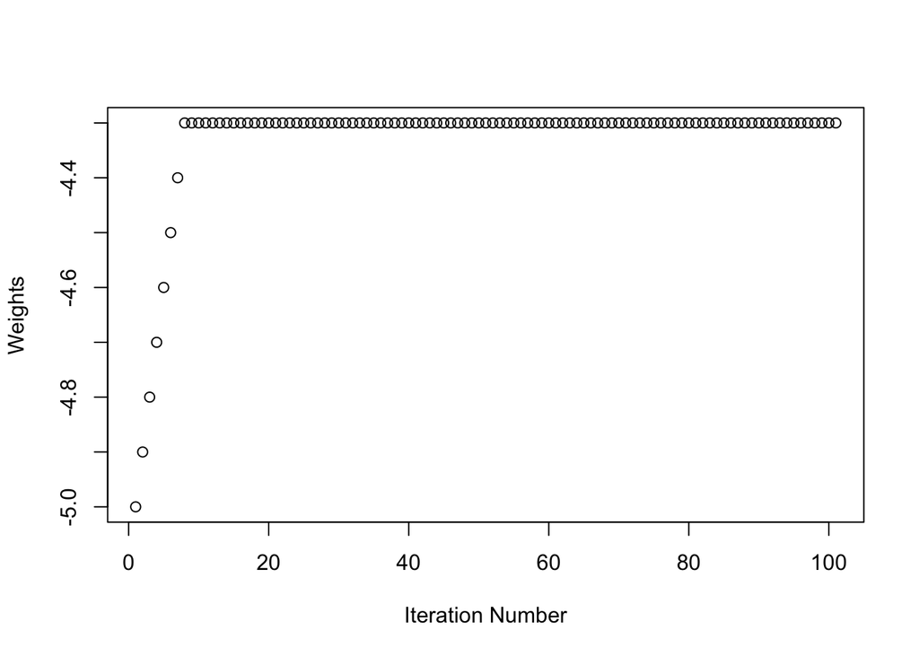

```r
g <- function(w) {
  sin(3*w)+(w^2)/3
}

results <- random_search1(g,10^-1,w0 = -5)
plot(1:101, results$weights, xlab = "Iteration Number", ylab = "Weights")
```

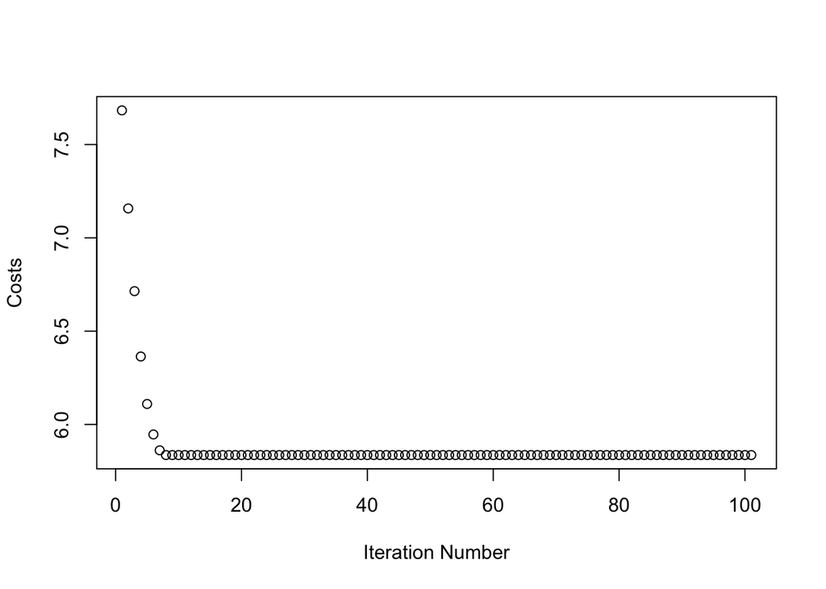

```r
plot(1:101, results$costs, xlab = "Iteration Number", ylab = "Costs")
```

### c)

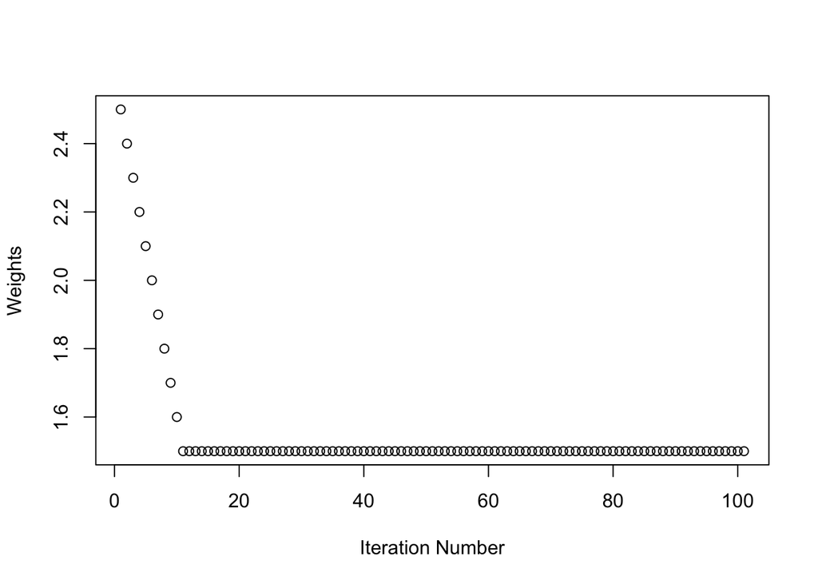

```r
results_2 <- random_search1(g,10^-1,w0 = 2.5)
plot(1:101, results_2$weights, xlab = "Iteration Number", ylab = "Weights")
```

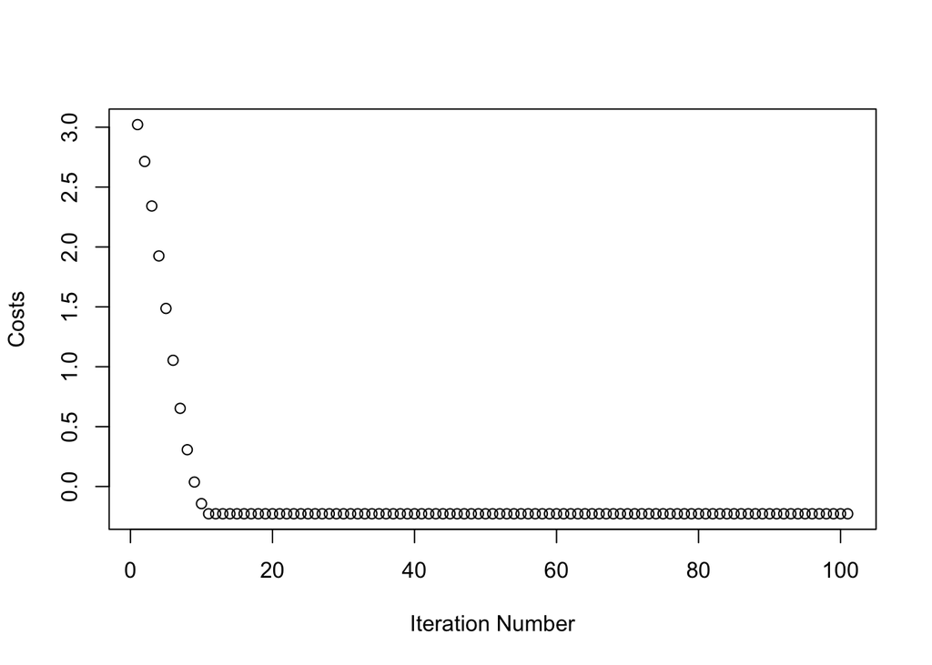

```r
plot(1:101, results_2$costs, xlab = "Iteration Number", ylab = "Costs")
```

### d)

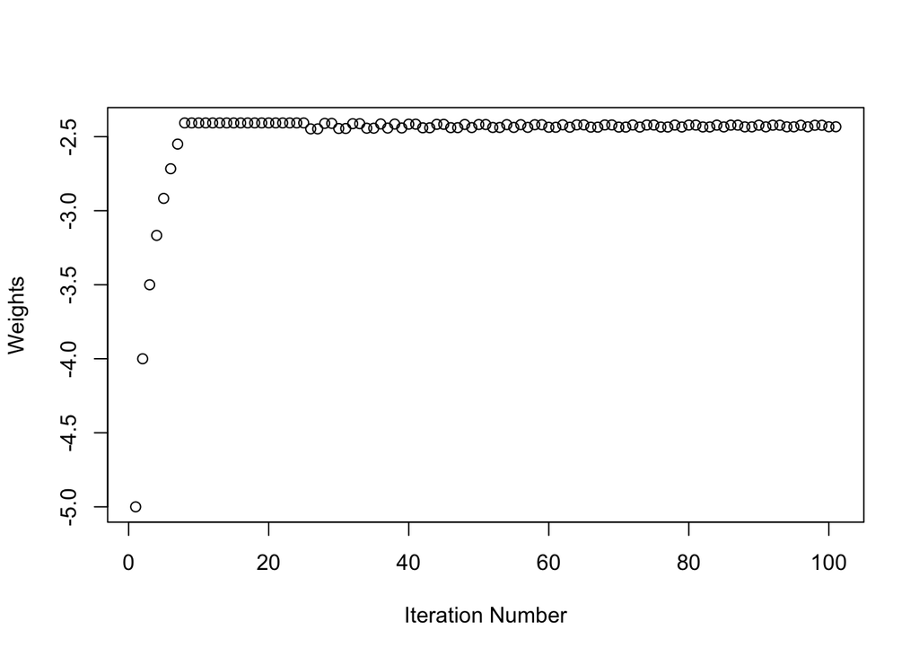

```r
results_3 <- random_search1(g,"diminishing",w0 = -5)
plot(1:101, results_3$weights, xlab = "Iteration Number", ylab = "Weights")
```

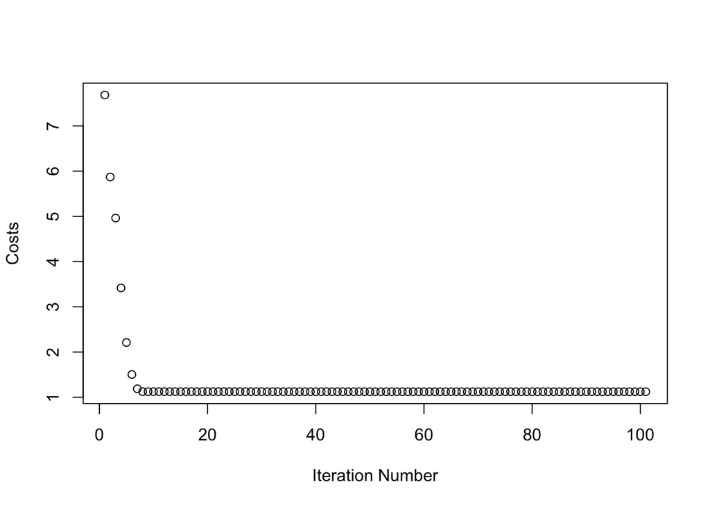

```r
plot(1:101, results_3$costs, xlab = "Iteration Number", ylab = "Costs")
```

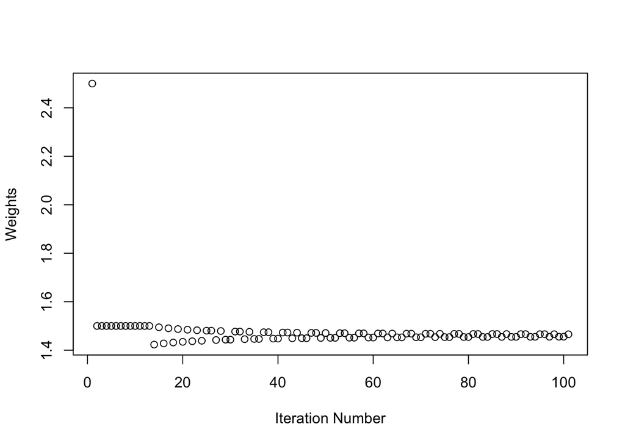

```r
results_4 <- random_search1(g,"diminishing",w0 = 2.5)
plot(1:101, results_4$weights, xlab = "Iteration Number", ylab = "Weights")
```

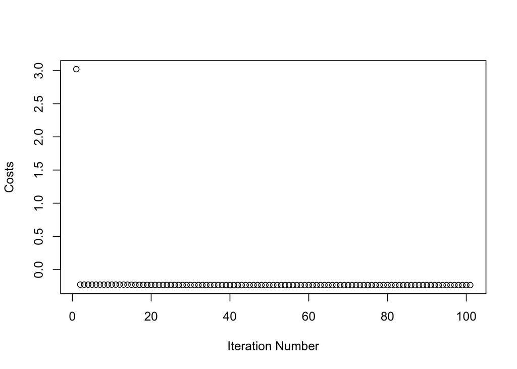

```r
plot(1:101, results_4$costs, xlab = "Iteration Number", ylab = "Costs")
```

### e)

We observe both the positives and the negatives with using a diminishing steplength. When we used our initial weight as -5, the execution with a fixed steplength saw a convergence to a proper local minimum, whereas the one with a diminishing steplength found a different minimum point of the function but not a local one. This is a downside of using a diminishing steplength as it might miss the closest local minimum in the first few iterations. However, when we used 2.5 as our initial weight, we observed that both methods converged to the proper local minimum, but the one with a diminishing steplength converged a lot faster. This is definitely a positive as faster convergence indicates higher efficiency.

## Problem 5

### a)

```r
random_search2 <- function(g, alpha_choice = 1, max_its = 100, num_samples = 1000, w0 = c(0,0)) {
  #random search function for a local minimum for a two dimensional input
  #Args:
  #g: an objective function
  #alpha_choice: if "diminishing", use diminishing steplength, if numerical, use that value as a fixed steplength
  #max_its: maximum number of iterations
  #num_samples: number of directions that will be sampled
  #w0: initial weight value (two-dimensional)
  #Return:
  #list containing the weight histories and the cost histories by the random search

  weight_history = matrix(w0)
  cost_history = g(w0)
  alpha = 0
  w = w0

  for (i in 1:max_its) {
    if (alpha_choice == 'diminishing') {
      alpha = 1/i
    } else {
      alpha = alpha_choice
    }

    # we will grab random unit directions in R2 space by using cosine and sine:
    angles <- runif(num_samples, min = 0, max = 2*pi)
    directions <- rbind(cos(angles), sin(angles))

    w_test <- w + alpha*directions
    g_vals <- numeric(0)
    for (j in 1:num_samples) {
      g_vals <- c(g_vals, g(w_test[,j]))
    }

    index <- which.min(g_vals)
    if (g(w_test[,index]) < g(w)) {
      d = directions[,index]
      w <- w + alpha*d
    }

    weight_history <- cbind(weight_history, w)
    cost_history <- c(cost_history, g(w))
  }

  list(weights = weight_history, costs = cost_history)
}
```

### b)

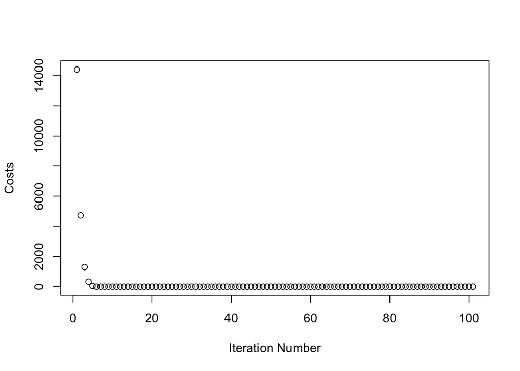

```r
g <- function(w) {
  100*(w[2]-w[1]^2)^2 + (w[1]-w[2])^2
}

results <- random_search2(g,w0 = c(-3,-3))
plot(1:101, results$costs, xlab = "Iteration Number", ylab = "Costs")
```

### c)

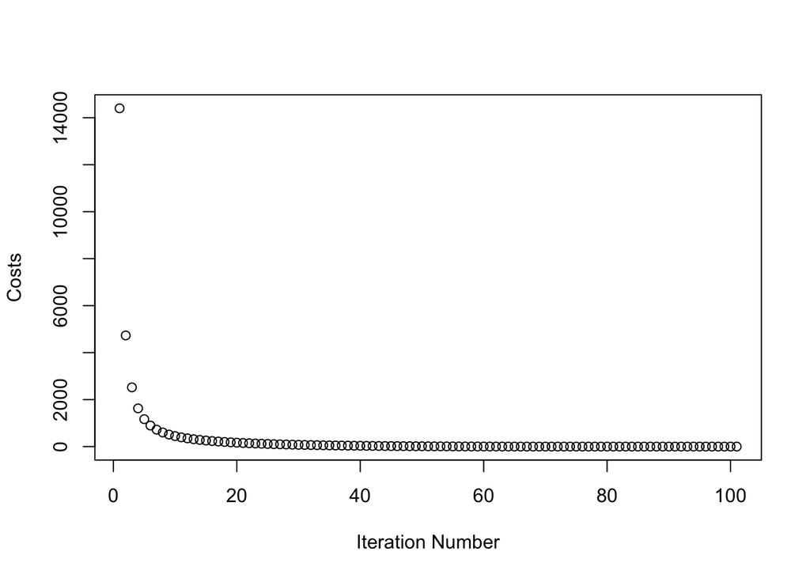

```r
results_2 <- random_search2(g,"diminishing",w0 = c(-3,-3))
plot(1:101, results_2$costs, xlab = "Iteration Number", ylab = "Costs")
```

### d)

Observing both plots, we notice that the one with diminishing steplength actually converged slower than one with the default fixed steplength of 1. This occurred because using a big steplength like 1 was able to get us to the minimum faster since the local minimum was relatively further away from the initial weight to begin with.